# Отчёт по лабораторной работе №11

Настройка NAT. Планирование

Илья Колонтырский

Российский университет дружбы народов, Москва, Россия

20.04.2026

# Цель и содержание работы

## Цель работы

Провести подготовительные мероприятия по подключению локальной сети организации к Интернету.

## Основные задачи

# Построение топологии сети

## Логическая схема L1

- В Cisco Packet Tracer построена схема подключения локальной сети к провайдеру и модельной сети Интернет.
- В топологию включены:
  - маршрутизаторы,
  - коммутаторы,
  - медиаконвертеры,
  - серверы,
  - оконечные устройства пользователей.
- Для сети провайдера и модельной сети Интернет добавлены:
  - **4 медиаконвертера Repeater-PT**;
  - **2 коммутатора Cisco 2960-24TT**;
  - **1 маршрутизатор Cisco 2811**;
  - **4 сервера**.

## Логическая схема L1

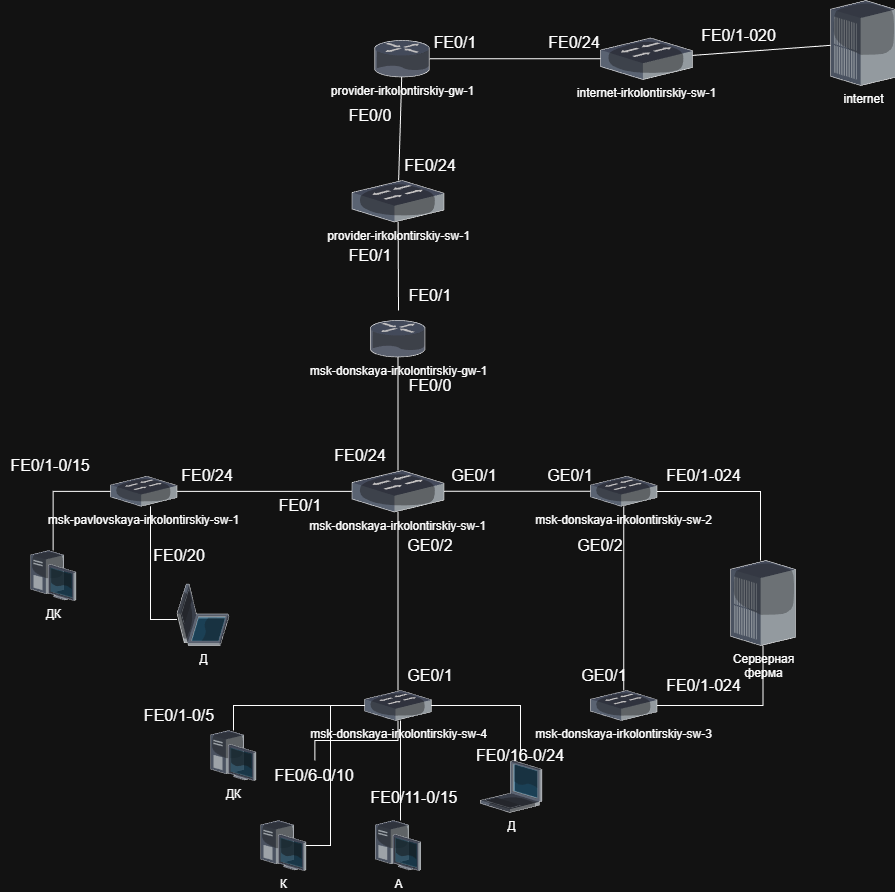

Схема L1 с добавлением сети провайдера и модельной сети Интернет

## Схема L2: VLAN-сегментация

- На канальном уровне выделены VLAN локальной сети, сети провайдера и модельного Интернета.
- Использованы следующие VLAN:
  - **VLAN 4** — сеть провайдера;
  - **VLAN 2** — сеть управления;
  - **VLAN 3** — серверная ферма;
  - **VLAN 101–104** — пользовательские сегменты.
- Между коммутаторами настроены магистральные соединения **trunk** для передачи нескольких VLAN.

## Схема L2: VLAN-сегментация

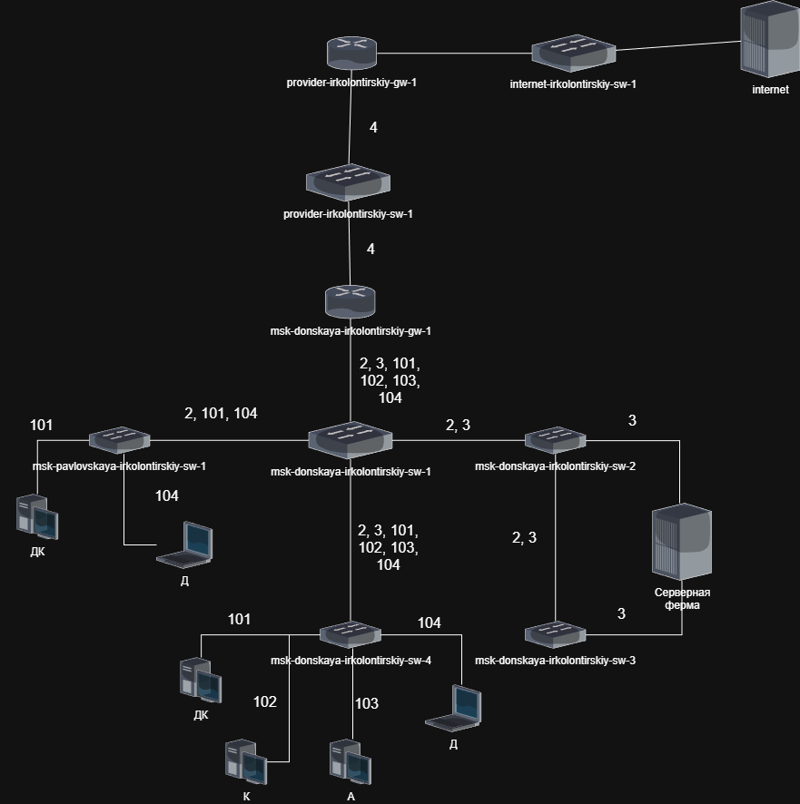

Схема L2 с указанием VLAN

## Схема L3: IP-адресация

- На сетевом уровне выполнено распределение адресного пространства.
- Использованы подсети:
  - **192.0.2.0/24** — модельная сеть Интернет;
  - **198.51.100.0/24** — сеть провайдера;
  - **10.128.0.0/24** — серверная ферма;
  - **10.128.1.0/24** — управление;
  - **10.128.3.0/24** — дисплейные классы;
  - **10.128.4.0/24** — кафедры;
  - **10.128.5.0/24** — администрация;
  - **10.128.6.0/24** — другие пользователи.

## Схема L3: IP-адресация

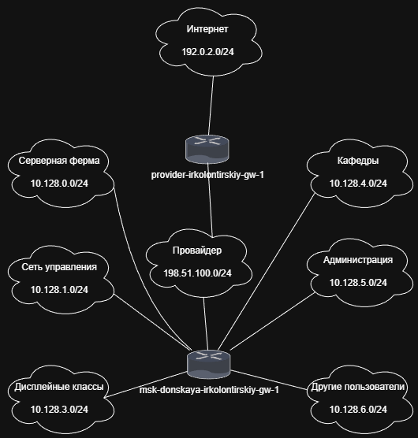

Схема L3 с IP-адресацией

# Размещение и подключение оборудования

## Добавление оборудования провайдера и Интернета

- На топологию предыдущего проекта добавлено оборудование сети провайдера и модельной сети Интернет.
- Размещены устройства:
  - маршрутизатор **provider-irkolontirskiy-gw-1**;
  - коммутатор **provider-irkolontirskiy-sw-1**;
  - коммутатор **internet-irkolontirskiy-sw-1**;
  - медиаконвертеры;
  - серверы модельного Интернета.
- Всем устройствам присвоены имена в соответствии со схемой.

## Общая логическая топология

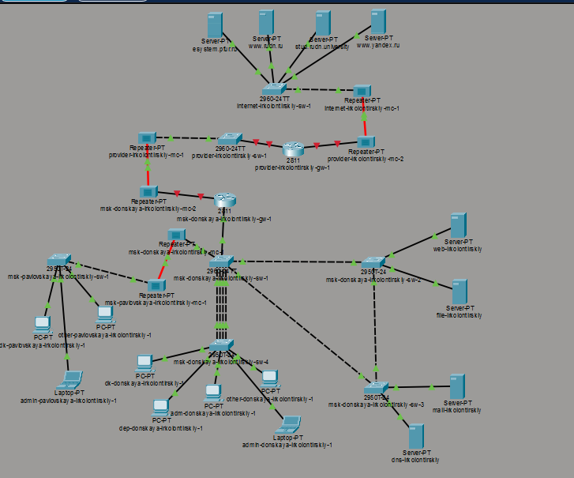

Общая логическая топология

## Физическая рабочая область

- В физической рабочей области добавлены отдельные здания:
  - для оборудования провайдера;
  - для оборудования модельной сети Интернет.
- Такое разделение позволило наглядно отразить размещение внешней инфраструктуры.

## Физическая схема размещения

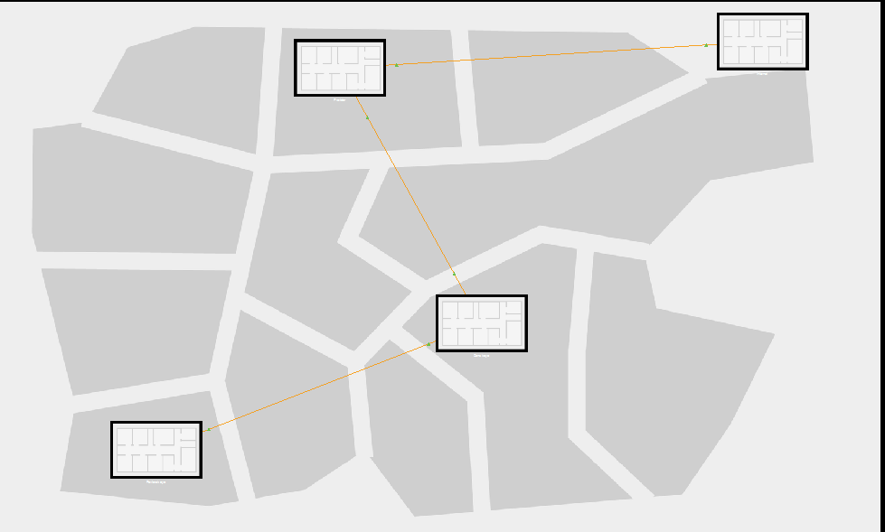

Физическая схема размещения

## Размещение оборудования провайдера

- Оборудование сети провайдера размещено в отдельном здании.
- В стойке установлены:
  - маршрутизатор,
  - коммутатор,
  - медиаконвертеры.

## Оборудование провайдера

[figure not shown]

Оборудование провайдера

## Размещение оборудования модельной сети Интернет

- Оборудование модельной сети Интернет размещено в отдельном здании.
- Серверы подключены к коммутатору.
- Реализована структура внешнего сегмента, имитирующего доступ к Интернет-ресурсам.

## Оборудование сети Интернет

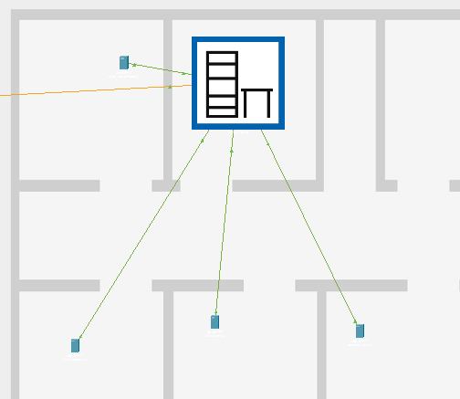

Оборудование сети Интернет

## Оборудование сети Интернет

[figure not shown]

Оборудование сети Интернет

## Настройка IP-адресов серверов

- На серверах модельной сети Интернет вручную настроены IP-адреса.
- Пример параметров:
  - **IP-адрес:** 192.0.2.13
  - **Маска:** 255.255.255.0
  - **Шлюз:** 192.0.2.1

## Настройка IP на сервере

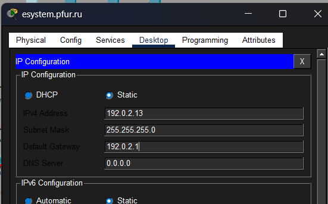

Настройка IP на сервере

## DNS-записи

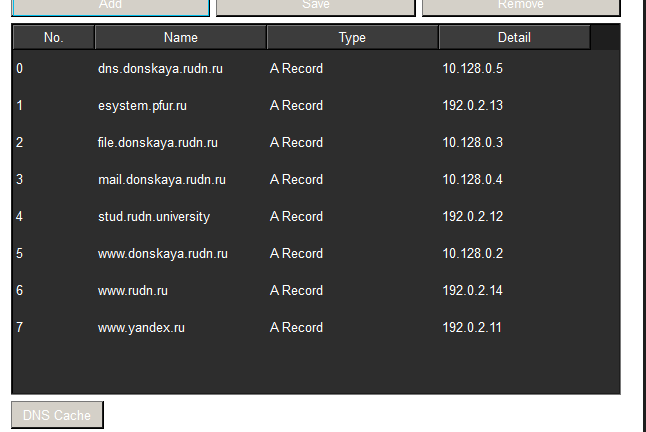

DNS записи

# Выводы

## Вывод

В ходе лабораторной работы была построена схема подключения локальной сети к модельной сети Интернет через сеть провайдера.

В результате выполнения работы:

- разработаны схемы уровней **L1, L2 и L3**;
- реализована физическая, канальная и сетевая структура сети;
- выполнено разделение сети на VLAN;
- настроена IP-адресация внутренних и внешних сегментов;
- подготовлены DNS-записи для доступа к ресурсам по доменным именам;
- сформирована работоспособная модель взаимодействия локальной инфраструктуры с внешними ресурсами.